# Market Indicators

Author

Jo Hardin

Published

August 6, 2026

Today we are measuring different market indicators using data from the [Curated open data on GitHub](https://github.com/datasets).

```r
library(tidyverse)
library(praise)
```

## Data

We collect data over time on: gold prices, natural gas prices, oil prices, the yield rate of the US 10y bond, volatility index, and the S & P 500.

```r
gold <- readr::read_csv(
  'https://raw.githubusercontent.com/datasets/gold-prices/refs/heads/main/data/monthly-processed.csv'
) |>
  rename(gold_price = Price)

oil <- readr::read_csv(
  'https://raw.githubusercontent.com/datasets/oil-prices/refs/heads/main/data/wti-monthly.csv'
) |>
  rename(oil_price = Price)

nat_gas <- readr::read_csv(
  'https://raw.githubusercontent.com/datasets/natural-gas/refs/heads/main/data/monthly-processed.csv'
) |>
  rename(gas_price = Price)

vix <- readr::read_csv(
  'https://raw.githubusercontent.com/datasets/finance-vix/refs/heads/main/data/vix-monthly.csv'
) |> # volatility index
  rename(vol_idx = Close)

bond <- readr::read_csv(
  'https://raw.githubusercontent.com/datasets/bond-yields-us-10y/refs/heads/main/data/monthly.csv'
) |> # bond yields us 10y
  rename(bond_rate = Rate)

temp <- readr::read_csv(
  'https://raw.githubusercontent.com/datasets/global-temp/refs/heads/main/data/monthly.csv'
) |>
  mutate(Date = lubridate::as_date(paste0(Year, "-01"))) |>
  rename(temp_diff = Mean) |>
  select(-Year, -Source)
# difference of that month from the average over all of the 20th century

sp <- readr::read_csv(
  'https://raw.githubusercontent.com/datasets/s-and-p-500/refs/heads/main/data/data.csv'
) |>
  select(Date, SP500)

full_data <- gold |>
  full_join(oil) |>
  full_join(nat_gas) |>
  full_join(vix) |>
  full_join(bond) |>
  full_join(temp) |>
  full_join(sp)
```

## Making a single plot

We start by making a single line plot over time, measuring oil prices.

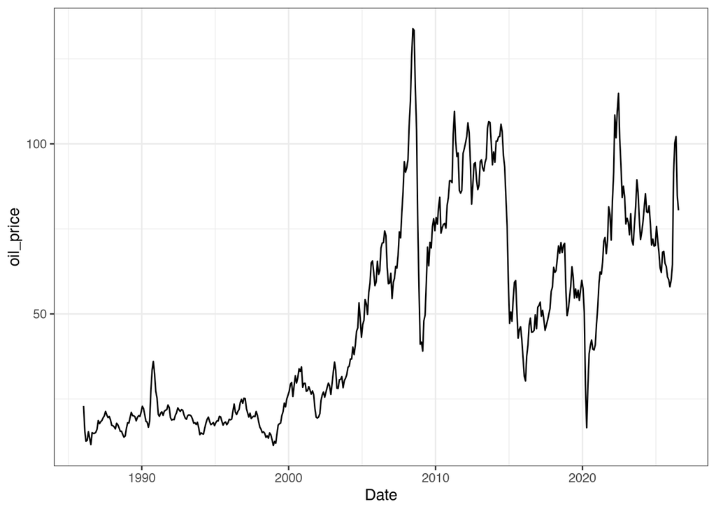

```r
full_data |>
  select(Date, oil_price) |>
  drop_na() |>
  ggplot(aes(x = Date, y = oil_price)) +
  geom_line() +
  theme_bw()
```

## Write a function

The function takes a variable name as the argument and makes a line plot over time for that variable. Note the `{ }` needed due to the non-standard evaluation.

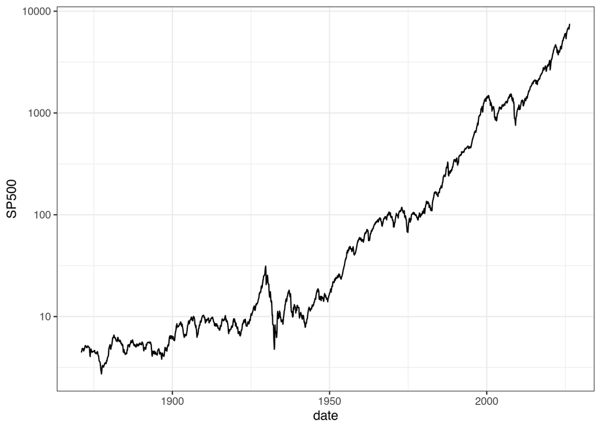

```r
plot_ts <- function(variable, log = TRUE) {
  if (log) {
    full_data |>
      select(Date, {{ variable }}) |>
      drop_na() |>
      ggplot(aes(x = Date, y = {{ variable }})) +
      geom_line() +
      theme_bw() +
      scale_y_log10() +
      labs(x = "date")
  } else {
    full_data |>
      select(Date, {{ variable }}) |>
      drop_na() |>
      ggplot(aes(x = Date, y = {{ variable }})) +
      geom_line() +
      theme_bw() +
      labs(x = "date")
  }
}

plot_ts(SP500, log = TRUE)
```

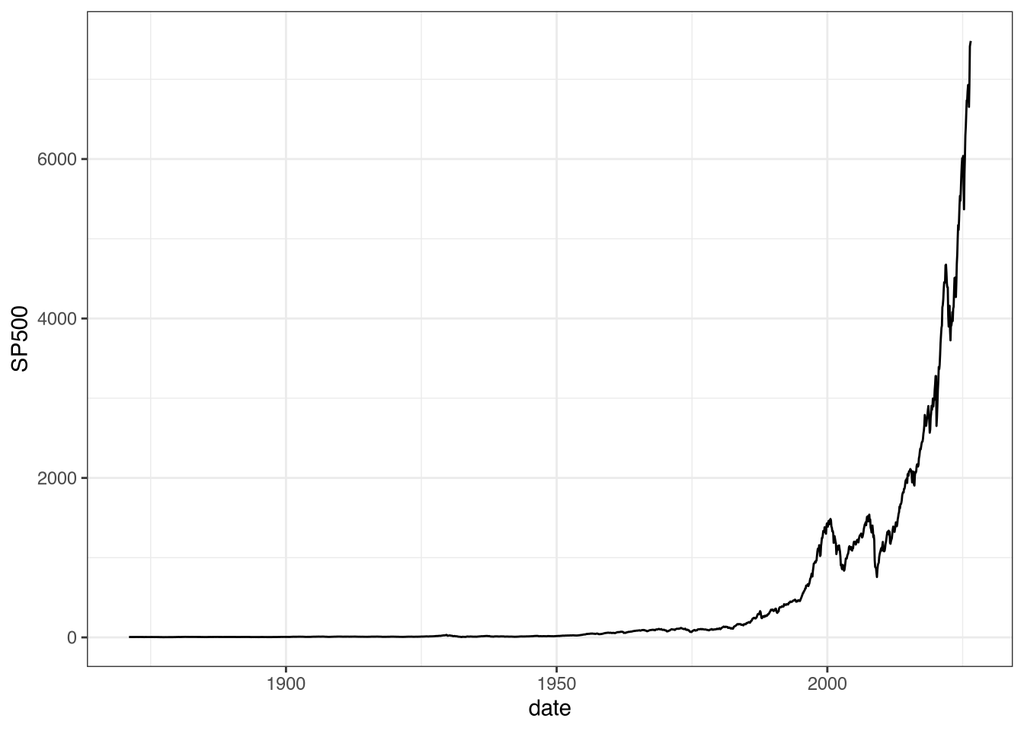

```r
plot_ts(SP500, log = FALSE)
```

## Mapping the function

Unforunately, the non-standard evaluation means that the function we wrote cannot be directly mapped. `map()` will go through the variables vector one at a time (e.g., `variables[1]`, `variables[2]`, etc.), and the name of the variable then needs to be translated into something that can be used in the tidy pipeline.

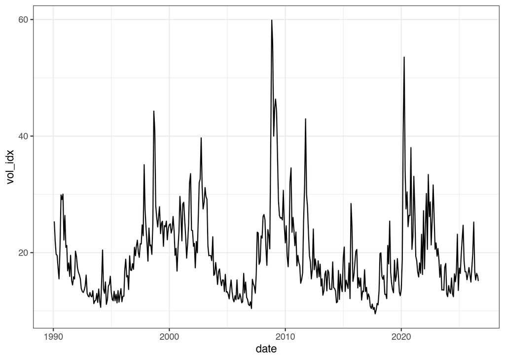

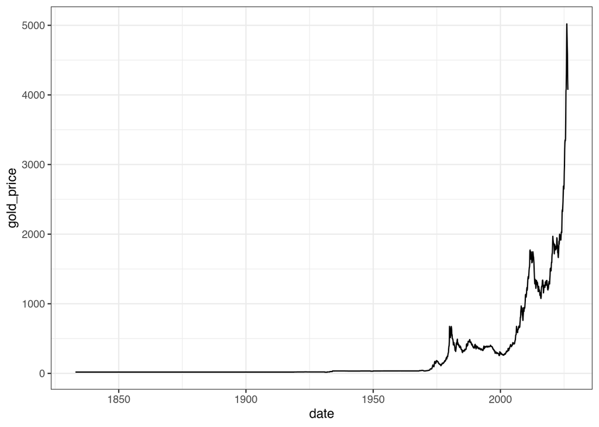

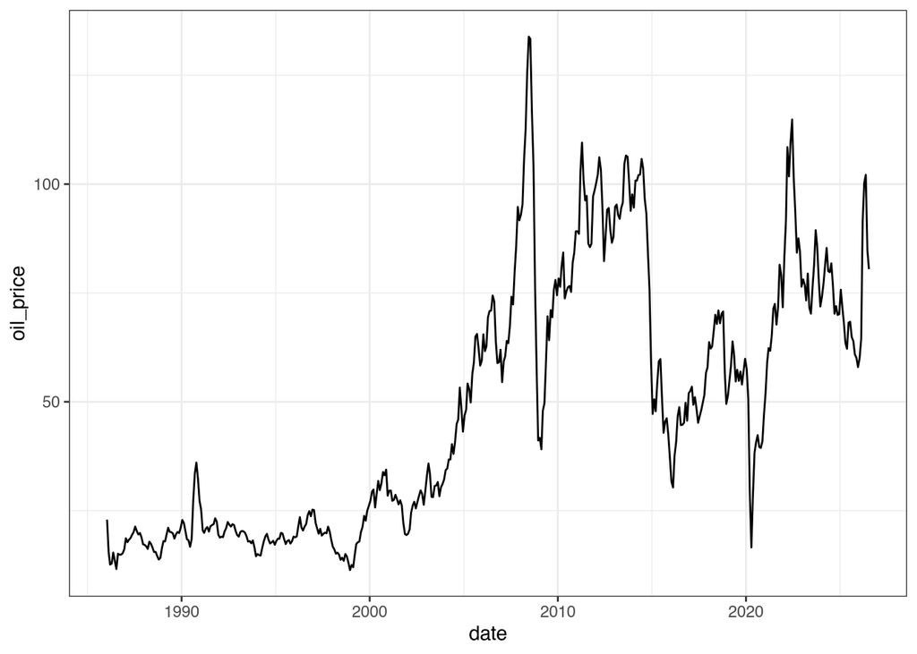

```r
variables <- c("vol_idx", "gold_price", "oil_price")

map(
  variables,
  \(v, log = TRUE) plot_ts(!!rlang::sym(v), log = log),
  log = FALSE
)
```

## Plotting multiple variables

Instead of looking at a single variable at a time, we might be interested in looking at multiple variables on the same plot. It is a little bit tricky because the variables are meausured on quite different scales, but some are comparable.

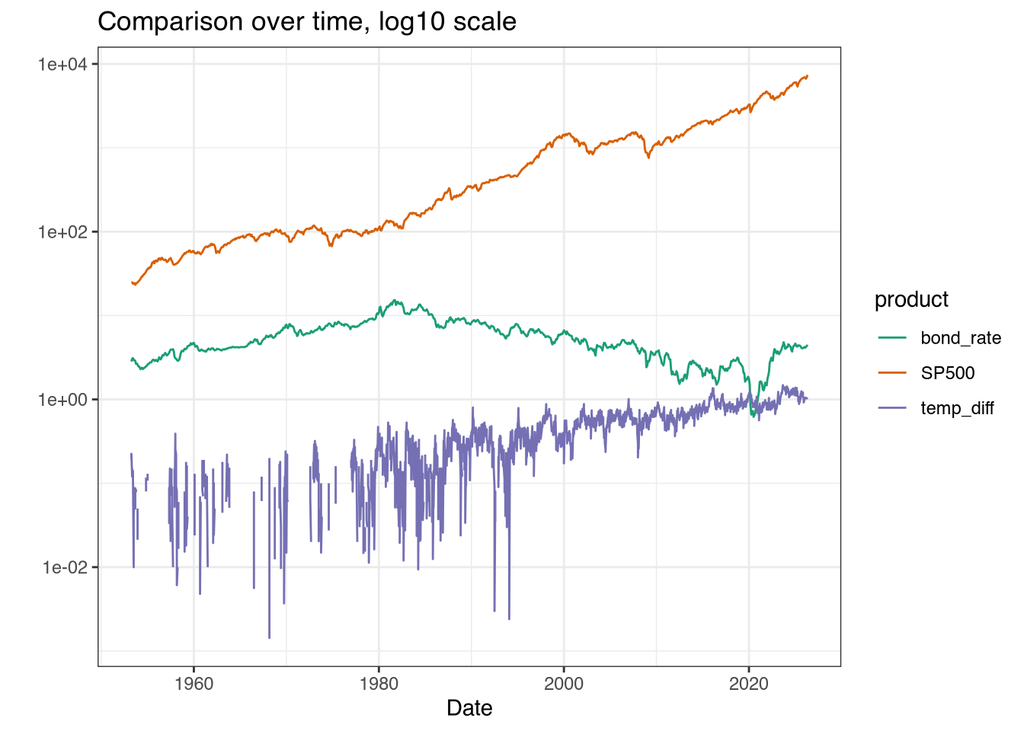

Comparing the US 10y yield bond rate, the S&P 500, and global temperature deviations from the average temperature for all of the 20th century.

```r
full_data |>
  select(Date, bond_rate, temp_diff, SP500) |>
  drop_na() |>
  pivot_longer(
    cols = -Date,
    names_to = "product",
    values_to = "value"
  ) |>
  ggplot(aes(x = Date, y = value, color = product)) +
  geom_line() +
  theme_bw() +
  scale_color_brewer(palette = "Dark2") +
  scale_y_log10() +
  labs(y = "", title = "Comparison over time, log10 scale")
```

## Using Shiny

We also played around with creating a [Shiny app](https://hardin47-market-indicator-explorer.share.connect.posit.cloud/) so the user could choose which variable to plot:

[interactive chart not shown]

```r
praise()
```

```
[1] "You are outstanding!"
```